# Manipulação de Dados

github.com/nacmarino/compartilhaR

## Elementos da Aula

1. A natureza dos dados
2. Métodos orientados ao conteúdo das colunas
3. Métodos orientados à tabela de dados
4. De largo para longo, e de volta outra vez

## A natureza dos dados

Um dado pode estar em duas diferentes 'fases de maturidade':

1. **Dados brutos (*raw data*):** são os dados em sua forma mais bruta, recém tabelados, com todos os erros de digitação, de unidade, e etc…
2. **Dados limpos (*tidy data*):** são os dados em uma forma limpa. Aqui, os dados brutos foram checados e corrigidos, erros de digitação desfeitos, unidades transformadas e etc. Todo e qualquer nova variável que pode ser gerada com os dados brutos está aqui.

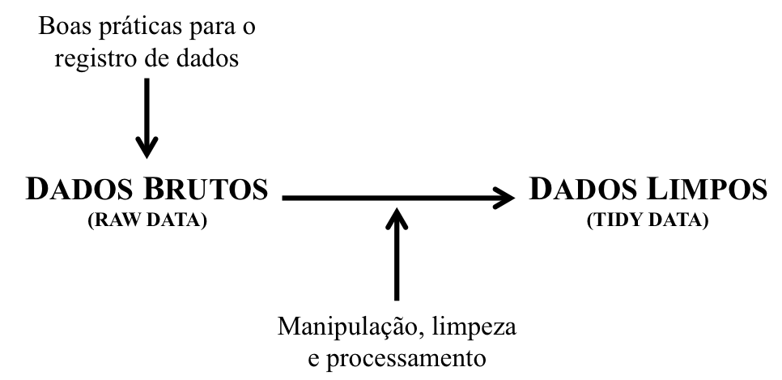

## A natureza dos dados

Além disso, mesmo os dados limpos podem não estar prontos para o uso ou, ainda, existirem dados derivados que serão o enfoque do seu trabalho.

1. **Dados para análise:** normalmente você não precisa de todos os dados que você limpou e/ou alguns dos dados úteis para a análise podem estar em outras tabelas. Assim, ao invés de começar toda a análise de dados removendo àquelas informações que não são úteis e buscando àquelas outras que são, você também pode criar recortes de dados que serão específicos para certas tarefas.
2. **Dados dos resultados das análises:** após rodar uma análise você pode exportar os resultados para fora do R. Ao fazer isso, estes dados retornam para a etapa número 1 - você precisa ajeitar os nomes das colunas, casas decimais,…

## A natureza dos dados

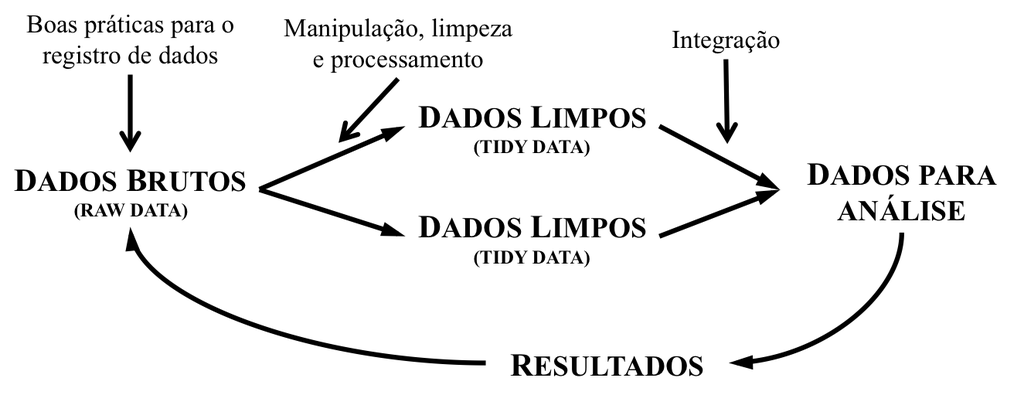

## A natureza dos dados

Outro ponto importante é que algumas análises exigem que os dados sejam apresentados de uma forma específica, o que também leva à duas formas de apresentar um mesmo dado.

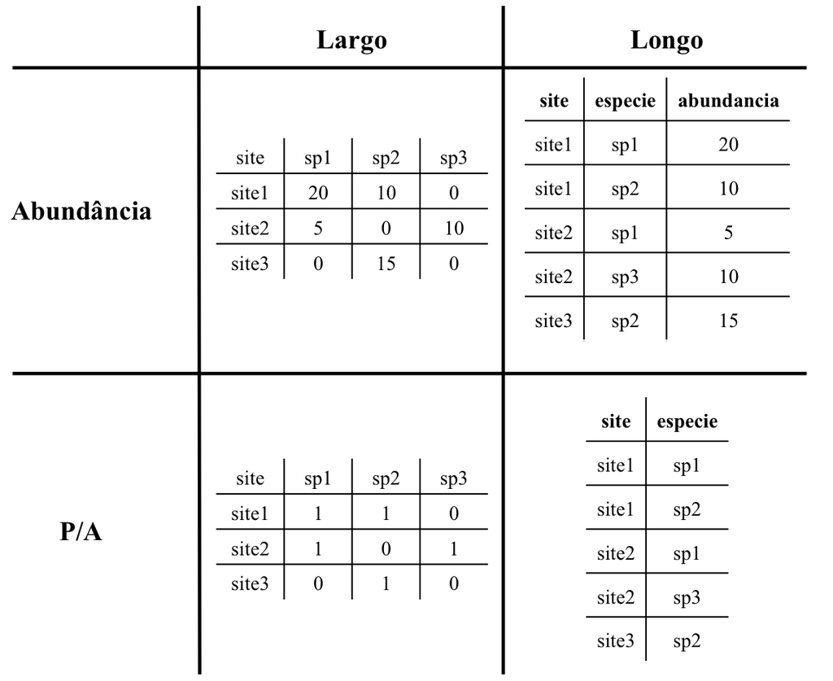

## A natureza dos dados

- Uma parte comum e bastante importante em todas essas fases é a manipulação, limpeza e processamento de dados (*tidying data*).
- É aqui que vamos preparar os dados para o uso em uma análise, para a criação de uma tabela com os resultados que encontramos e, também, para a confecção de figuras.
- Mas também é onde:
  - Você normalmente faz tudo de forma manual;
  - Você não mantém registro escrito do que está fazendo;
  - Você vai criar múltiplas versões de uma mesma planilha, pois não sabe se as coisas que você está manipulando, mexendo e editando fazem sentido ou estão corretas;
  - Você perde tempo da forma mais repetitiva possível - a não ser que você use uma linguagem de programação! =]

## Objetivos da manipulação, limpeza e processamento de dados

1. Criar e/ou eliminar novas variáveis (normalmente, nas colunas);
2. Substituir valores que foram digitados errados;
3. Substituir palavras e expressões que estejam má digitadas ou onde hajam nomes melhores;
4. Modificar os nomes das variáveis (normalmente, as colunas);
5. Modificar os nomes dos níveis das variáveis (normalmente, os valores das linhas de uma determinada coluna);
6. Separar a informação de uma coluna em duas ou mais;
7. Rearranjar a ordem das colunas;
8. Selecionar as colunas que vão compor os dados que serão analisados;
9. Passar os dados de um formato longo para um formato largo (e vice-versa);
10. Juntar dados que estão separados em planilhas diferentes;
11. Remover `NA`s;
12. Selecionar sub-conjuntos dos dados para destinações diferentes (e.g., diferentes pedaços de *tidy data*);
13. Fazer algumas transformações na estrutura original dos dados para criar um *tidy data* mais condizente com o que você vai precisar na hora das análises.

## `tidyverse`

- Existem muitas funções na `base` do R que podem ser utilizadas para a manipulação, limpeza e processamento de dados.
- No entanto, muitos dos pacotes mais úteis para estas tarefas estão organizados dentro de um pacote 'guarda-chuva', chamado `tidyverse`.

```r
library(tidyverse)
tidyverse_packages()
```

```
##  [1] "broom"       "cli"         "crayon"      "dplyr"       "dbplyr"
##  [6] "forcats"     "ggplot2"     "haven"       "hms"         "httr"
## [11] "jsonlite"    "lubridate"   "magrittr"    "modelr"      "purrr"
## [16] "readr"       "readxl\n(>=" "reprex"      "rlang"       "rstudioapi"
## [21] "rvest"       "stringr"     "tibble"      "tidyr"       "xml2"
## [26] "tidyverse"
```

## Exercício 1

- Vamos utilizar todas as seis tabelas de dados abaixo nas tarefas e exercícios a seguir.
1. Importe para o R as seguintes tabelas:
   - **dados dos projetos.csv**, e atribua este arquivo ao objeto **projetos**;
   - **publicacoes.xls**, e atribua este arquivo ao objeto **publicacoes**;
   - **revistas.xlsx**, e atribua este arquivo ao objeto **revistas**.
2. Também, carregue dois conjuntos de dados que estão disponíveis dentro de pacotes:
   - **varechem** e **varespec**, disponíveis no pacote `vegan`;
   - **gapminder** disponível no pacote `gapminder`.

## Métodos orientados ao conteúdo das colunas

- É muito comum que cometamos erros de digitação ao preenchermos uma tabela e uma vez que estes erros sejam detectados, normalmente consertamos eles manualmente na tabela de dados brutos.
- No entanto, é bastante preferível que estes consertos sejam realizados através da própria linguagem de programação, a fim de que toda e qualquer alteração e editoração que você tenha feito a um conjunto de dados fique registrado e você não se esqueça no futuro.
- Outra vantagem disso é que qualquer alteração futura que precise ser feita será muito mais fácil, uma vez que apenas será necessário mudar uma única linha de comando - ao invés de repetir manualmente todas as etapas da manipulação, limpeza e processamento de dados.
- Este processo também é útil quando queremos criar novas variáveis baseado nos valores daquelas que já existem.

## Substituição de valores

- Duas funções bastante úteis para modificar valores são `sub` e `gsub`.

```r
sub(pattern = "é", replacement = "e", x = "América do Norte")
```

```
## [1] "America do Norte"
```

```r
sub(pattern = "E", replacement = "e", x = "AmErica do NortE")
```

```
## [1] "America do NortE"
```

```r
gsub(pattern = "E", replacement = "e", x = "AmErica do NortE")
```

```
## [1] "America do Norte"
```

## Substituição de valores

- Estas funções também podem ser utilizadas para remover espaços e outros caracteres (como `.`, `,`, `-`, e etc).

```r
gsub(pattern = "  ", replacement = " ", x = "Rio  de  Janeiro")
```

```
## [1] "Rio de Janeiro"
```

```r
sub(pattern = "/", replacement = " ", x = "PPGE/UFRJ")
```

```
## [1] "PPGE UFRJ"
```

```r
sub(pattern = "-", replacement = " ", x = c("Pé-de-moleque", "PPGE-UFRJ"))
```

```
## [1] "Pé de-moleque" "PPGE UFRJ"
```

## Substituição de valores

- Também podemos empregar estas funções em vetores e colunas.
- No exemplo abaixo, utilizamos a função `unique` para termos uma noção de quais são os valores únicos que aparecem dentro da coluna **Chamada** do objeto **projetos** - você consegue encontrar algum erro em algum dos elementos?

```r
unique(x = projetos$Chamada)
```

```
##  [1] "Universal - Faixa A"             "BJT"
##  [3] "Universal - Faixa C"             "Incubadoras"
##  [5] "PPBio - Rede Mata Atletica"      "Universal - Faixa B"
##  [7] "PVE"                             "Linha 1 - Faixa - B"
##  [9] "PPBio - Rede Amazonia Ocidental" "Linha 1: Universidades"
## [11] "Pesca"                           "PELD"
## [13] "PPBio - Rede Cerrado"            "PPBio - Rede Campos Sulinos"
## [15] "Alemanha DFG"                    "GEOMA - Rede GEOMA"
## [17] "Ilhas Oceanicas"                 "PV"
## [19] "Argentina - CNPq/CONICET"        "Belgica"
## [21] "CsF"
```

## Exercício 2

1. Substitua o erro de digitação que você encontrou pela grafia certa da palavra.
2. Avalie se esta substiuição corrigiu esta entrada na coluna **Chamada** do objeto **projetos**.
3. Caso não tenha sido corrigida, o que você acha que aconteceu? Como podemos realizar essa correção?

## Edição de valores em um vetor

- Valores e nomes de variáveis com espaço, muito longos, com caracteres especiais, em caixa alta e etc, podem causar erros durante a indexação e operação de algumas funções. Portanto, é sempre desejável que simplifiquemos estes nomes e tornemos eles consistentes, para evitar possíveis dores de cabeça. Para isso, quatro funções podem ser bastante úteis: `tolower`, `toupper`, `make.names` e `abbreviate`.

```r
## vamos criar um vetor com as 10 primeiras publicacoes que aparecem na coluna Publicacao do objeto revistas
exemplo <- revistas$Publicacao[1:10]
exemplo
```

```
##  [1] "Acta Amazonica"
##  [2] "Acta Biologica Colombiana"
##  [3] "Acta Botanica Brasilica"
##  [4] "Acta Limnologica Brasiliensia"
##  [5] "Acta Oecologica"
##  [6] "Acta Scientiarum - Biological Sciences"
##  [7] "Acta Tropica"
##  [8] "African Journal of Agricultural Research"
##  [9] "Agraria"
## [10] "Agroforestry Systems"
```

## Edição de valores em um vetor

```r
# tolower faz com que todos os caracteres fiquem em caixa baixa
tolower(exemplo)
# toupper faz com que todos os caracteres fiquem em caixa alta
toupper(exemplo)
# make.names faz com que os nomes das colunas mudem para um formato mais amigável a um computador
make.names(exemplo)
# e, se você achar que os nomes estão muito longos, podemos usar a função abbreviate
abbreviate(exemplo)
```

## Exercício 3

- Observe que os nomes das colunas do objeto **projetos** não são de todo consistentes. Você conseguiria modificar o nome dessas colunas, fazendo com que todos os caracteres ficassem em caixa baixa? Dica: utilize `names(projetos)` ou `colnames(projetos)` para visualizar o nome das colunas desse `data.frame`.

## Combinando vetores

- Você também pode unir informações presentes em dois ou mais vetores (ou colunas) em um único elemento, utilizando as funções `paste` e `paste0`. Como exemplo, vamos unir a sigla da Unidade da Federação com o nome da Cidade que estão no objeto **projetos**.

```r
## compare as formas abaixo
paste(projetos$cidade, projetos$uf)
paste(projetos$cidade, projetos$uf, sep = "/")
paste0(projetos$cidade, projetos$uf)
paste0(projetos$cidade, "/", projetos$uf)
```

## Exercício 4

- De que forma podemos criar o `data.frame` abaixo? (apenas as primeiras linhas são apresentadas aqui por conta do tamanho)

```
##    id_coordenador        localidade
## 1               1     Rio Grande/RS
## 2               2     Sao Carlos/SP
## 3               3       Curitiba/PR
## 4               4         Recife/PE
## 5               5    Joao Pessoa/PB
## 6               6         Manaus/AM
## 7               7         Manaus/AM
## 8               8        Goiania/GO
## 9               9 Rio de Janeiro/RJ
## 10             10 Rio de Janeiro/RJ
## 11             11       Salvador/BA
## 12             12 Belo Horizonte/MG
```

## Edição de vetores baseado em lógica

- Finalmente, também podemos editar e alterar os valores de uma coluna baseado em testes e argumentos lógicos.
- Uma função importante neste sentido é o `ifelse`.

```r
## um vetor contendo o sexo de 10 pessoas
sexo <- rep(x = c("M", "F"), each = 5)
sexo
```

```
##  [1] "M" "M" "M" "M" "M" "F" "F" "F" "F" "F"
```

```r
## substituindo
ifelse(test = sexo == "M", yes = "masculino", no = "feminino")
```

```
##  [1] "masculino" "masculino" "masculino" "masculino" "masculino"
##  [6] "feminino"  "feminino"  "feminino"  "feminino"  "feminino"
```

## Exercício 5

- Adicione uma coluna ao objeto **revistas** que especifique se a revista em questão é nacional ou internacional.

## Edição de vetores baseado em lógica

- Mas o que acontece se tivéssemos três categorias diferentes de sexo?

```r
## um vetor contendo o sexo de 15 pessoas
sexo <- rep(x = c("M", "F", "ND"), each = 5)
sexo
```

```
##  [1] "M"  "M"  "M"  "M"  "M"  "F"  "F"  "F"  "F"  "F"  "ND" "ND" "ND" "ND"
## [15] "ND"
```

```r
## substituindo
ifelse(test = sexo == "M", yes = "masculino", no = "feminino")
```

## Edição de vetores baseado em lógica

- Cada elemento de um vetor que não passa no teste do `ifelse` recebe o valor que determinamos. Portanto, quando temos um vetor com múltiplos valores e queremos substituir apenas um deles devemos fazer essa operação em cadeia.

```r
# se o resultado for verdadeiro substitua por 'masculino', caso contrario, substitua pelo valor de sexo naquela posicao
(sexo <- ifelse(test = sexo == "M", yes = "masculino", no = sexo))

# se o resultado for verdadeiro substitua por 'feminino', caso contrario, substitua pelo valor de sexo naquela posicao
(sexo <- ifelse(test = sexo == "F", yes = "feminino", no = sexo))

# se o resultado for verdadeiro substitua por 'feminino', caso contrario, substitua pelo valor de sexo naquela posicao
(sexo <- ifelse(test = sexo == "ND", yes = "não determinado", no = sexo))
```

## Exercício 6

- Você consegue realizar a mesma operação que acabamos demonstrar sem criar um objeto a cada etapa?

```r
## um vetor contendo o sexo de 15 pessoas
sexo <- rep(x = c("M", "F", "ND"), each = 5)
sexo
```

```
##  [1] "M"  "M"  "M"  "M"  "M"  "F"  "F"  "F"  "F"  "F"  "ND" "ND" "ND" "ND"
## [15] "ND"
```

## Editando todo o conteúdo das colunas de uma tabela

- O `ifelse` também pode ser aplicado à toda a tabela de dados, o que pode nos ajudar a transformar uma matriz de abundância em uma de presenca/ausência.

```r
ifelse(test = varespec > 0, yes = 1, no = 0)
```

```
##    Callvulg Empenigr Rhodtome Vaccmyrt Vaccviti Pinusylv Descflex Betupube
## 18        1        1        0        0        1        1        0        0
## 15        1        1        0        1        1        1        0        0
## 24        1        1        0        0        1        1        0        0
## 27        0        1        1        1        1        0        1        0
## 23        0        1        0        0        1        1        0        0
## 19        0        1        0        1        1        1        1        0
## 22        1        1        1        1        1        1        1        1
## 16        1        1        0        1        1        1        0        0
## 28        0        1        1        1        1        1        1        0
## 13        1        1        1        1        1        1        0        0
```

## Exercício 7

- Uma tarefa muito comum para quem trabalha com ecologia de comunidades é quantificar a abundância total e a riqueza de espécies em uma dada comunidade. Nesse sentido, você poderia criar um `data.frame` com estas duas quantidades para cada comunidade apresentada no conjunto de dados `varespec`?
  - Dica: veja o arquivo de ajuda das funções `colSums` e `rowSums`.

## Métodos orientados à tabela de dados {#anchor3}

- As funções apresentadas anteriormente são úteis para realizar algumas manipulações básicas e mais comuns do conteúdo de um tabela. No entanto, existe muitas outras coisas que precisamos fazer durante a manipulação, limpeza e processamento de dados, onde muitas delas são feitas de forma complexa ou pouco intuitiva através das funções da `base` do R.
- Algumas dessas tarefas são:
  - Renomear o nome de uma coluna específica (na `base`, indexação);
  - Ordenar uma tabela de acordo com uma ou mais colunas (na `base`, indexação + `sort` e/ou `order`);
  - Selecionar algumas colunas específicas ou mudar a ordem delas (na `base`, indexação ou escrever o nome de cada uma - entre aspas);
  - Filtrar uma tabela de dados de acordo com critérios lógicos (na `base`, indexação por lógica ou `subset`);
  - Adicionar uma nova coluna a um conjunto de dados (na `base`, indexação);
  - Realizar uma operação para cada nível de uma categoria que defina as observações (na `base`, loop ou funções loop (`by`, `apply`, `lapply`,…));
  - Separar as informações de uma coluna em múltiplas colunas (na `base`, `strsplit` + `unlist` + `rbind.data.frame`);
  - Transformar uma tabela de dados do formato largo para o formato longo e vice-versa.

## Métodos orientados à tabela de dados

- Note que todas essas ações podem ser definidas por **verbos**, que foram implementas através dos pacotes `dplyr` e `tidyr` no `tidyverse`.
  - `rename`: renomeia as colunas da tabela;
  - `arrange`: ordena as linhas de uma tabela de acordo com uma condição;
  - `select`: seleciona uma ou mais colunas de acordo com seu nome ou com um padrão;
  - `filter`: filtra as linhas de acordo com uma ou mais condições;
  - `mutate`: adiciona novas variáveis à tabela;
  - `group_by`: agrupa observações antes de realizar opereações;
  - `summarise`: sumariza múltiplos valores para um único;
  - `separate`: separa uma coluna em múltiplas colunas;
  - `spread`: transforma uma tabela do **formato longo para o formato largo**;
  - `gather`: transforma uma tabela do **formato largo para o formato longo**.

## Funcionamento geral do verbos do `tidyverse`

- Unidade primária de manipulação é o `data.frame` e ou `tibble`, e as colunas presentes neles;
- Todo o verbo é interpretado através de *lazy evaluation*: a primeira coisa que você fornece para a função é o conjunto de dados; a partir daí, a própria função entende que tudo o que você for fazer é em referência às informações que estão ali - elimina a necessidade de indexação.
- A idéia geral aqui é encurtar o espaço entre o que você quer fazer e o resultado (ou seja, entre a pergunta e a resposta), sem importar o tamanho do conjunto de dados.
- Para provar estes pontos, vamos utilizar o conjunto de dados `gapminder` que carregamos no início da aula.

## `gapminder`

```r
gapminder
```

```
## # A tibble: 1,704 x 6
##    country     continent  year lifeExp      pop gdpPercap
##    <fct>       <fct>     <int>   <dbl>    <int>     <dbl>
##  1 Afghanistan Asia       1952    28.8  8425333      779.
##  2 Afghanistan Asia       1957    30.3  9240934      821.
##  3 Afghanistan Asia       1962    32.0 10267083      853.
##  4 Afghanistan Asia       1967    34.0 11537966      836.
##  5 Afghanistan Asia       1972    36.1 13079460      740.
##  6 Afghanistan Asia       1977    38.4 14880372      786.
##  7 Afghanistan Asia       1982    39.9 12881816      978.
##  8 Afghanistan Asia       1987    40.8 13867957      852.
##  9 Afghanistan Asia       1992    41.7 16317921      649.
## 10 Afghanistan Asia       1997    41.8 22227415      635.
## # ... with 1,694 more rows
```

## `rename`

Utilizada para renomear colunas específicas, contornando a necessidade de indexação.

```r
rename(.data = gapminder, pais = country, continente = continent, ano = year)
```

```
## # A tibble: 1,704 x 6
##    pais        continente   ano lifeExp      pop gdpPercap
##    <fct>       <fct>      <int>   <dbl>    <int>     <dbl>
##  1 Afghanistan Asia        1952    28.8  8425333      779.
##  2 Afghanistan Asia        1957    30.3  9240934      821.
##  3 Afghanistan Asia        1962    32.0 10267083      853.
##  4 Afghanistan Asia        1967    34.0 11537966      836.
##  5 Afghanistan Asia        1972    36.1 13079460      740.
##  6 Afghanistan Asia        1977    38.4 14880372      786.
##  7 Afghanistan Asia        1982    39.9 12881816      978.
##  8 Afghanistan Asia        1987    40.8 13867957      852.
##  9 Afghanistan Asia        1992    41.7 16317921      649.
## 10 Afghanistan Asia        1997    41.8 22227415      635.
## # ... with 1,694 more rows
```

## `arrange`

Utilizada para ordernar as linhas de uma tabela em ordem crescente ou decrescente.

```r
arrange(.data = gapminder, year)
```

```
## # A tibble: 1,704 x 6
##    country     continent  year lifeExp      pop gdpPercap
##    <fct>       <fct>     <int>   <dbl>    <int>     <dbl>
##  1 Afghanistan Asia       1952    28.8  8425333      779.
##  2 Albania     Europe     1952    55.2  1282697     1601.
##  3 Algeria     Africa     1952    43.1  9279525     2449.
##  4 Angola      Africa     1952    30.0  4232095     3521.
##  5 Argentina   Americas   1952    62.5 17876956     5911.
##  6 Australia   Oceania    1952    69.1  8691212    10040.
##  7 Austria     Europe     1952    66.8  6927772     6137.
##  8 Bahrain     Asia       1952    50.9   120447     9867.
##  9 Bangladesh  Asia       1952    37.5 46886859      684.
## 10 Belgium     Europe     1952    68    8730405     8343.
## # ... with 1,694 more rows
```

## `arrange`

Utilizada para ordernar as linhas de uma tabela em ordem crescente ou decrescente.

```r
arrange(.data = gapminder, desc(year))
```

```
## # A tibble: 1,704 x 6
##    country     continent  year lifeExp       pop gdpPercap
##    <fct>       <fct>     <int>   <dbl>     <int>     <dbl>
##  1 Afghanistan Asia       2007    43.8  31889923      975.
##  2 Albania     Europe     2007    76.4   3600523     5937.
##  3 Algeria     Africa     2007    72.3  33333216     6223.
##  4 Angola      Africa     2007    42.7  12420476     4797.
##  5 Argentina   Americas   2007    75.3  40301927    12779.
##  6 Australia   Oceania    2007    81.2  20434176    34435.
##  7 Austria     Europe     2007    79.8   8199783    36126.
##  8 Bahrain     Asia       2007    75.6    708573    29796.
##  9 Bangladesh  Asia       2007    64.1 150448339     1391.
## 10 Belgium     Europe     2007    79.4  10392226    33693.
## # ... with 1,694 more rows
```

## `arrange`

Pode comportar tantas colunas quantas aquelas que você desejar.

```r
arrange(.data = gapminder, desc(year), lifeExp)
```

```
## # A tibble: 1,704 x 6
##    country                  continent  year lifeExp      pop gdpPercap
##    <fct>                    <fct>     <int>   <dbl>    <int>     <dbl>
##  1 Swaziland                Africa     2007    39.6  1133066     4513.
##  2 Mozambique               Africa     2007    42.1 19951656      824.
##  3 Zambia                   Africa     2007    42.4 11746035     1271.
##  4 Sierra Leone             Africa     2007    42.6  6144562      863.
##  5 Lesotho                  Africa     2007    42.6  2012649     1569.
##  6 Angola                   Africa     2007    42.7 12420476     4797.
##  7 Zimbabwe                 Africa     2007    43.5 12311143      470.
##  8 Afghanistan              Asia       2007    43.8 31889923      975.
##  9 Central African Republic Africa     2007    44.7  4369038      706.
## 10 Liberia                  Africa     2007    45.7  3193942      415.
## # ... with 1,694 more rows
```

## Exercício 8

1. Qual foi o projeto que mais gastou recursos dentre aqueles financiados pelo CNPq?
2. Qual foi o coordenador que terminou o doutorado há mais tempo?
3. Qual o coordenador que tem o maior índice H e não fez pós-doutorado?

## `select`

Utilizada para selecionar uma ou mais colunas de acordo com seu nome.

```r
# somente o pais, ano e gdp per capita
select(.data = gapminder, country, year, gdpPercap)
```

```
## # A tibble: 1,704 x 3
##    country      year gdpPercap
##    <fct>       <int>     <dbl>
##  1 Afghanistan  1952      779.
##  2 Afghanistan  1957      821.
##  3 Afghanistan  1962      853.
##  4 Afghanistan  1967      836.
##  5 Afghanistan  1972      740.
##  6 Afghanistan  1977      786.
##  7 Afghanistan  1982      978.
##  8 Afghanistan  1987      852.
##  9 Afghanistan  1992      649.
## 10 Afghanistan  1997      635.
## # ... with 1,694 more rows
```

## `select`

Utilizada para selecionar uma ou mais colunas de acordo com seu nome.

```r
# apenas algumas variáveis e reordenando elas
select(.data = gapminder, gdpPercap, country:lifeExp)
```

```
## # A tibble: 1,704 x 5
##    gdpPercap country     continent  year lifeExp
##        <dbl> <fct>       <fct>     <int>   <dbl>
##  1      779. Afghanistan Asia       1952    28.8
##  2      821. Afghanistan Asia       1957    30.3
##  3      853. Afghanistan Asia       1962    32.0
##  4      836. Afghanistan Asia       1967    34.0
##  5      740. Afghanistan Asia       1972    36.1
##  6      786. Afghanistan Asia       1977    38.4
##  7      978. Afghanistan Asia       1982    39.9
##  8      852. Afghanistan Asia       1987    40.8
##  9      649. Afghanistan Asia       1992    41.7
## 10      635. Afghanistan Asia       1997    41.8
## # ... with 1,694 more rows
```

## `select`

Também pode ser utilizada para selecionar colunas baseado em um padrão específico, utilizando os argumentos auxiliares:

- `starts_with()`: seleciona colunas que comecem com um certo padrão em seu nome;
- `ends_with()`: seleciona colunas que terminem com um certo padrão em seu nome;
- `contains()`: seleciona colunas que contenham um certo padrão em seu nome.

## Exercício 9

- Do conjunto de dados do `gapminder`:
  - Remova apenas a coluna `country` de `gapminder`;
  - Selecione as colunas `continent`, `year` e `pop`;
  - Com o resultado da última operação, ordene as linhas de acordo com a ordem decrescente dos anos;
  - Além de ordenar as linhas pela ordem crescente dos continentes, ordene agora também o tamanho da população.
- Do conjunto de dados dos projetos, selecione a coluna com o ID do coordenador do projeto e todas as colunas que representam de recursos gastos em cada projeto.

## `filter`

Utilizada para filtrar uma tabela de acordo com as condições que você determina.

```r
# apenas os dados do Brasil
filter(.data = gapminder, country == "Brazil")
```

```
## # A tibble: 12 x 6
##    country continent  year lifeExp       pop gdpPercap
##    <fct>   <fct>     <int>   <dbl>     <int>     <dbl>
##  1 Brazil  Americas   1952    50.9  56602560     2109.
##  2 Brazil  Americas   1957    53.3  65551171     2487.
##  3 Brazil  Americas   1962    55.7  76039390     3337.
##  4 Brazil  Americas   1967    57.6  88049823     3430.
##  5 Brazil  Americas   1972    59.5 100840058     4986.
##  6 Brazil  Americas   1977    61.5 114313951     6660.
##  7 Brazil  Americas   1982    63.3 128962939     7031.
##  8 Brazil  Americas   1987    65.2 142938076     7807.
##  9 Brazil  Americas   1992    67.1 155975974     6950.
## 10 Brazil  Americas   1997    69.4 168546719     7958.
## 11 Brazil  Americas   2002    71.0 179914212     8131.
## 12 Brazil  Americas   2007    72.4 190010647     9066.
```

## `filter`

Utilizada para filtrar uma tabela de acordo com as condições que você determina.

```r
# dados das Americas, apenas os 20 últimos anos
filter(.data = gapminder, continent == "Americas", year > 1996)
```

```
## # A tibble: 75 x 6
##    country   continent  year lifeExp       pop gdpPercap
##    <fct>     <fct>     <int>   <dbl>     <int>     <dbl>
##  1 Argentina Americas   1997    73.3  36203463    10967.
##  2 Argentina Americas   2002    74.3  38331121     8798.
##  3 Argentina Americas   2007    75.3  40301927    12779.
##  4 Bolivia   Americas   1997    62.0   7693188     3326.
##  5 Bolivia   Americas   2002    63.9   8445134     3413.
##  6 Bolivia   Americas   2007    65.6   9119152     3822.
##  7 Brazil    Americas   1997    69.4 168546719     7958.
##  8 Brazil    Americas   2002    71.0 179914212     8131.
##  9 Brazil    Americas   2007    72.4 190010647     9066.
## 10 Canada    Americas   1997    78.6  30305843    28955.
## # ... with 65 more rows
```

## `filter`

Utilizada para filtrar uma tabela de acordo com as condições que você determina.

```r
# dados das Americas e Europa, apenas os 20 últimos anos
filter(.data = gapminder, continent == "Americas" | continent == "Europe", year > 1996)
```

```
## # A tibble: 165 x 6
##    country   continent  year lifeExp      pop gdpPercap
##    <fct>     <fct>     <int>   <dbl>    <int>     <dbl>
##  1 Albania   Europe     1997    73.0  3428038     3193.
##  2 Albania   Europe     2002    75.7  3508512     4604.
##  3 Albania   Europe     2007    76.4  3600523     5937.
##  4 Argentina Americas   1997    73.3 36203463    10967.
##  5 Argentina Americas   2002    74.3 38331121     8798.
##  6 Argentina Americas   2007    75.3 40301927    12779.
##  7 Austria   Europe     1997    77.5  8069876    29096.
##  8 Austria   Europe     2002    79.0  8148312    32418.
##  9 Austria   Europe     2007    79.8  8199783    36126.
## 10 Belgium   Europe     1997    77.5 10199787    27561.
## # ... with 155 more rows
```

## `filter`

Podemos utilizar o argumento lógico `%in%` para selecionar múltiplos elementos de uma mesma coluna.

```r
# dados das Americas Europa e Oceania, apenas os 20 últimos anos
filter(.data = gapminder, continent %in% c("Americas", "Europe", "Oceania"), year > 1996)
```

```
## # A tibble: 171 x 6
##    country   continent  year lifeExp      pop gdpPercap
##    <fct>     <fct>     <int>   <dbl>    <int>     <dbl>
##  1 Albania   Europe     1997    73.0  3428038     3193.
##  2 Albania   Europe     2002    75.7  3508512     4604.
##  3 Albania   Europe     2007    76.4  3600523     5937.
##  4 Argentina Americas   1997    73.3 36203463    10967.
##  5 Argentina Americas   2002    74.3 38331121     8798.
##  6 Argentina Americas   2007    75.3 40301927    12779.
##  7 Australia Oceania    1997    78.8 18565243    26998.
##  8 Australia Oceania    2002    80.4 19546792    30688.
##  9 Australia Oceania    2007    81.2 20434176    34435.
## 10 Austria   Europe     1997    77.5  8069876    29096.
## # ... with 161 more rows
```

## `filter`

E podemos criar uma função para fazer o inverso do `%in%`!

```r
## criando a função
`%nin%` <- Negate(f = `%in%`)

## removendo os dados das Americas, Europa e Oceania
filter(.data = gapminder, continent %nin% c("Americas", "Europe", "Oceania"), year > 1996)
```

```
## # A tibble: 255 x 6
##    country     continent  year lifeExp      pop gdpPercap
##    <fct>       <fct>     <int>   <dbl>    <int>     <dbl>
##  1 Afghanistan Asia       1997    41.8 22227415      635.
##  2 Afghanistan Asia       2002    42.1 25268405      727.
##  3 Afghanistan Asia       2007    43.8 31889923      975.
##  4 Algeria     Africa     1997    69.2 29072015     4797.
##  5 Algeria     Africa     2002    71.0 31287142     5288.
##  6 Algeria     Africa     2007    72.3 33333216     6223.
##  7 Angola      Africa     1997    41.0  9875024     2277.
##  8 Angola      Africa     2002    41.0 10866106     2773.
##  9 Angola      Africa     2007    42.7 12420476     4797.
## 10 Bahrain     Asia       1997    73.9   598561    20292.
## # ... with 245 more rows
```

## Exercício 10

- Quais foram os projetos financiados no estado do Rio de Janeiro?
- Quais os projetos financiados no estado do Rio de Janeiro foram coordenados por mulheres?
- Onde estão localizados os bolsistas de produtividade 1C ou 1D que mais gastaram recursos?

## `mutate`

Cria uma nova coluna na tabela de dados, inclusive usando as próprias colunas que estão sendo criadas dentro da função naquele momento.

```r
mutate(.data = gapminder, log_gdp = log(gdpPercap), exp_gdp = exp(log_gdp))
```

```
## # A tibble: 1,704 x 8
##    country     continent  year lifeExp      pop gdpPercap log_gdp exp_gdp
##    <fct>       <fct>     <int>   <dbl>    <int>     <dbl>   <dbl>   <dbl>
##  1 Afghanistan Asia       1952    28.8  8425333      779.    6.66    779.
##  2 Afghanistan Asia       1957    30.3  9240934      821.    6.71    821.
##  3 Afghanistan Asia       1962    32.0 10267083      853.    6.75    853.
##  4 Afghanistan Asia       1967    34.0 11537966      836.    6.73    836.
##  5 Afghanistan Asia       1972    36.1 13079460      740.    6.61    740.
##  6 Afghanistan Asia       1977    38.4 14880372      786.    6.67    786.
##  7 Afghanistan Asia       1982    39.9 12881816      978.    6.89    978.
##  8 Afghanistan Asia       1987    40.8 13867957      852.    6.75    852.
##  9 Afghanistan Asia       1992    41.7 16317921      649.    6.48    649.
## 10 Afghanistan Asia       1997    41.8 22227415      635.    6.45    635.
## # ... with 1,694 more rows
```

## `transmute`

Similar ao `mutate`, mas elimina todas as outras colunas ao retornar o resultado

```r
transmute(.data = gapminder, log_gdp = log(gdpPercap), exp_gdp = exp(log_gdp))
```

```
## # A tibble: 1,704 x 2
##    log_gdp exp_gdp
##      <dbl>   <dbl>
##  1    6.66    779.
##  2    6.71    821.
##  3    6.75    853.
##  4    6.73    836.
##  5    6.61    740.
##  6    6.67    786.
##  7    6.89    978.
##  8    6.75    852.
##  9    6.48    649.
## 10    6.45    635.
## # ... with 1,694 more rows
```

## Exercício 11

- Crie uma nova coluna na tabelas **processos** que seja a combinação das colunas `cidade` e `uf`.

## `group_by`

Agrupa as observações de acordo com os níveis de uma ou mais variáveis presentes nas colunas. É excelente para ser combinado com outras funções.

```r
group_by(.data = gapminder, continent)
```

```
## # A tibble: 1,704 x 6
## # Groups:   continent [5]
##    country     continent  year lifeExp      pop gdpPercap
##    <fct>       <fct>     <int>   <dbl>    <int>     <dbl>
##  1 Afghanistan Asia       1952    28.8  8425333      779.
##  2 Afghanistan Asia       1957    30.3  9240934      821.
##  3 Afghanistan Asia       1962    32.0 10267083      853.
##  4 Afghanistan Asia       1967    34.0 11537966      836.
##  5 Afghanistan Asia       1972    36.1 13079460      740.
##  6 Afghanistan Asia       1977    38.4 14880372      786.
##  7 Afghanistan Asia       1982    39.9 12881816      978.
##  8 Afghanistan Asia       1987    40.8 13867957      852.
##  9 Afghanistan Asia       1992    41.7 16317921      649.
## 10 Afghanistan Asia       1997    41.8 22227415      635.
## # ... with 1,694 more rows
```

## `group_by` + `filter`

```r
## quais sao os paises em cada continente que tiveram menor expectativa de vida em toda a serie
filter(.data = group_by(.data = gapminder, continent), lifeExp == min(lifeExp))
```

```
## # A tibble: 5 x 6
## # Groups:   continent [5]
##   country     continent  year lifeExp      pop gdpPercap
##   <fct>       <fct>     <int>   <dbl>    <int>     <dbl>
## 1 Afghanistan Asia       1952    28.8  8425333      779.
## 2 Australia   Oceania    1952    69.1  8691212    10040.
## 3 Haiti       Americas   1952    37.6  3201488     1840.
## 4 Rwanda      Africa     1992    23.6  7290203      737.
## 5 Turkey      Europe     1952    43.6 22235677     1969.
```

## Exercício 12

- Quais são os coordenadores estrangeiros e brasileiros que tem indice H menor do que 15 e se terminaram o doutorado antes de 1990?
- Quais são os coordenadores que mais gastaram recursos por classe de bolsa de produtividade?

## `group_by` + `summarise`

Uma das grandes vantagens do `group_by` é observada quando combinamos ele com a função `summarise`, que aplica uma mesma função para cada nível da variável agrupadora e retorna uma tabela com o sumário estatístico.

```r
## expectativade vida media por continente
summarise(.data = group_by(.data = gapminder, continent), expectativa_media = mean(lifeExp))
```

```
## # A tibble: 5 x 2
##   continent expectativa_media
##   <fct>                 <dbl>
## 1 Africa                 48.9
## 2 Americas               64.7
## 3 Asia                   60.1
## 4 Europe                 71.9
## 5 Oceania                74.3
```

## `group_by` + `summarise`

- Podemos agrupar os dados de acordo com várias colunas.
- Para quebrar o agrupamento basta utilizarmos a função `ungroup`.

```r
## expectativamente de vida media por continente por ano
summarise(.data = group_by(.data = gapminder, continent, year), expectativa_media = mean(lifeExp))
```

```
## # A tibble: 60 x 3
## # Groups:   continent [?]
##    continent  year expectativa_media
##    <fct>     <int>             <dbl>
##  1 Africa     1952              39.1
##  2 Africa     1957              41.3
##  3 Africa     1962              43.3
##  4 Africa     1967              45.3
##  5 Africa     1972              47.5
##  6 Africa     1977              49.6
##  7 Africa     1982              51.6
##  8 Africa     1987              53.3
##  9 Africa     1992              53.6
## 10 Africa     1997              53.6
## # ... with 50 more rows
```

## Exercício 13

- Utilizando o objeto **revistas**, adicione uma coluna indicando se cada revista é nacional ou estrangeira e calcule o índice SJR médio destas duas categorias.
- Calcule o índice H médio de coordenadores de projetos brasileiros e extrangeiros de acordo com o tipo de bolsa de produtividade recebido, e considerando apenas os coordenadores que terminaram o doutorado após o ano 2000.

## O operador **pipe**: `%>%`

- Em toda língua, todo texto fica difícil de compreender quando emendarmos frases sem adicionar uma pontuação.
- Acabamos de ver isso acontecendo também quando utilizamos a linguagem R, ao utilizarmos resultado de um verbo diretamente no processamento de outro verbo do `tidyverse`.
- Isso faz com que todo o código que escrevamos rapidamente fique complexo demais de se ler ou, ainda, exija a criação de diversas etapas intermediárias.

```r
## muito complexo
summarise(.data = group_by(.data = select(.data = gapminder, country, continent, gdpPercap), continent, country),
          media_gdp = mean(gdpPercap))

## muito enfadonho
passo1 <- select(.data = gapminder, country, continent, gdpPercap)
passo2 <- group_by(.data = passo1, continent, country)
passo3 <- summarise(.data = passo2, media_gdp = mean(gdpPercap))
```

## O operador **pipe**: `%>%`

- A fim de descomplicar a escrita do código e fazer com que ele fique mais claro, o operador `pipe` é implementado no ambiente de trabalho quando você carrega o `tidyverse`.
- O operador `pipe`, representado pelo símbolo `%>%`, é implementado especificamente através do pacote `dplyr`.
- O atalho do teclado para o `pipe` é **Control + Shift + M** (no Windows) ou **Command + Shift + M** (no MAC).
- Um exemplo do uso do `pipe` no mesmo contexto apresentado no slide anterior:

```r
gapminder %>%
  select(country, continent, gdpPercap) %>%
  group_by(continent, country) %>%
  summarise(media_gdp = mean(gdpPercap))
```

## O operador **pipe**: `%>%`

- O `pipe` funciona potencializando o *lazy evaluation* nos verbos do `tidyverse`.
- Ele passa o `data.frame`/`tibble` de uma linha de comando ou resultante do processamento de um verbo para o argumento `.data` do verbo que o segue - assim como a pontuação e adjuntos conectam frases no português.

```r
gapminder %>%
  select(country, continent, gdpPercap) %>%
  group_by(continent, country) %>%
  summarise(media_gdp = mean(gdpPercap))
```

## O operador **pipe**: `%>%`

- Como veremos nas outras aulas, o `pipe` também pode ser empregado no processamento de outras funções, incluindo a extração e processamento de resultados de análises.

```r
gapminder %>%
  group_by(country) %>%
  summarise(expectativa = mean(lifeExp), gdp = mean(gdpPercap)) %>%
  lm(gdp ~ expectativa, data = .) %>%
  summary(.)
```

## Exercício 14

- Determine o número médio, mínimo e máximo do número de citações recebidas em cada uma das revistas onde os artigos científicos foram publicados (dados presentes no objeto __publicacoes).
- Repita o procedimento acima, mas calcule também o desvio padrão e o número total de artigos publicados em cada revista (utilize a função `n()` para tal).

## `drop_na`

- Uma das formas de remover as linhas contendo `NA` na `base` do R é através da indexação por lógica, utilizando o `is.na`.
- Você pode fazer a mesma coisa no `tidyverse`, utilizando a função `drop_na` - especificando inclusive de qual coluna você quer que os `NA` sejam removidas.

```r
drop_na(data = publicacoes, citacoes)
```

```
## # A tibble: 548 x 6
##       Processo    id titulo                    journal      ISSN  citacoes
##          <dbl> <dbl> <chr>                     <chr>        <chr>    <dbl>
##  1 40060020137     1 Larval Biology of Anthop… Journal of … 1536…        4
##  2 40060020137     2 Seasonal variation in di… Biotropica   0106…        0
##  3 40060020137     3 Biology of the immature … Revista Bra… 0085…        3
##  4 40060020137     4 Immature Stages and Ecol… Journal of … 0024…        0
##  5 40060020137     5 Importance of Habitat He… Environment… 0046…        2
##  6 40060020137     6 Sexual Dimorphism and Al… Journal of … 1536…        0
##  7 40060020137     7 Species composition and … Zoologia (C… 1984…        3
##  8 40060020137     8 Temporal Dynamics of Fru… Florida Ent… 0015…        0
##  9 40060020137     9 Temporal Occurrence of T… Environment… 0046…        2
## 10 40060020137    10 The Abundance of Special… Florida Ent… 0015…        0
## # ... with 538 more rows
```

## `separate`

Utilizado para separar as informações de uma coluna em várias colunas diferentes.

```r
projetos %>%
  separate(col = inicio, into = c("dia", "mes", "ano"), sep = "/")
```

```
## # A tibble: 119 x 28
##     processo chamada        id_coordenador sexo  dia   mes   ano   termino
##        <dbl> <chr>                   <int> <chr> <chr> <chr> <chr> <chr>
##  1   4.86e10 Universal - F…              1 M     06    11    12    05/11/…
##  2   4.01e10 BJT                         2 F     12    09    12    11/09/…
##  3   4.82e10 Universal - F…              3 M     08    11    13    30/11/…
##  4   4.72e10 Universal - F…              4 F     14    12    12    31/12/…
##  5   4.76e10 Universal - F…              5 M     30    10    13    31/10/…
##  6   4.82e10 Universal - F…              6 M     07    05    13    05/05/…
##  7   4.80e10 Universal - F…              7 M     19    11    12    18/11/…
##  8   4.46e10 Incubadoras                 8 M     02    08    16    31/12/…
##  9   4.58e10 PPBio - Rede …              9 M     12    12    12    11/12/…
## 10   4.72e10 Universal - F…             10 M     28    11    12    30/11/…
## # ... with 109 more rows, and 20 more variables: instituicao <chr>,
## #   uf <chr>, cidade <chr>, regiao <chr>, duracao <int>, brasileiro <chr>,
## #   produtividade <chr>, doutorado <int>, doutorado_exterior <chr>,
## #   sanduiche <chr>, posdoc <chr>, indiceh <int>, bolsa_contratado <dbl>,
## #   bolsa_gasto <int>, capital_contratado <dbl>, capital_gasto <dbl>,
## #   custeio_contratado <dbl>, custeio_gasto <dbl>, total_fornecido <dbl>,
## #   total_gasto <dbl>
```

## `rownames_to_column`

Por padrão, um `tibble` não comporta nomes nas linhas, o que pode ser particularmente problemático quando convertemos um `data.frame` para àquela classe de objeto. No entanto, podemos usar a função `rownames_to_column` para adicionar uma coluna que contenha o nome de cada linha.

```r
varespec <- varespec %>%
  rownames_to_column(var = "site")
varespec
```

```
##    site Callvulg Empenigr Rhodtome Vaccmyrt Vaccviti Pinusylv Descflex
## 1    18     0.55    11.13     0.00     0.00    17.80     0.07     0.00
## 2    15     0.67     0.17     0.00     0.35    12.13     0.12     0.00
## 3    24     0.10     1.55     0.00     0.00    13.47     0.25     0.00
## 4    27     0.00    15.13     2.42     5.92    15.97     0.00     3.70
## 5    23     0.00    12.68     0.00     0.00    23.73     0.03     0.00
## 6    19     0.00     8.92     0.00     2.42    10.28     0.12     0.02
## 7    22     4.73     5.12     1.55     6.05    12.40     0.10     0.78
## 8    16     4.47     7.33     0.00     2.15     4.33     0.10     0.00
## 9    28     0.00     1.63     0.35    18.27     7.13     0.05     0.40
## 10   13    24.13     1.90     0.07     0.22     5.30     0.12     0.00
## 11   14     3.75     5.65     0.00     0.08     5.30     0.10     0.00
## 12   20     0.02     6.45     0.00     0.00    14.13     0.07     0.00
## 13   25     0.00     6.93     0.00     0.00    10.60     0.02     0.10
## 14    7     0.00     5.30     0.00     0.00     8.20     0.00     0.05
```

[output cut: 135 more lines]

## De largo para longo, e de volta outra vez

- Uma tarefa que normalmente precisamos fazer é também converter uma tabela do formato largo para o formato longo e vice-versa.
- Além disso, as vezes é mais fácil converter uma tabela para um desses formatos para realizar rapidamente um processamento ou manipulação de dados (e.g., aplicar uma mesma transformação apenas às colunas que contenham números).
- Existem duas funções que podem nos ajudar nesse sentido:
  - `gather`, para juntar as informações de múltiplas colunas em uma única coluna;
  - `spread`, para espalhar as informações de uma única coluna para múltiplas colunas.

## `gather`

```r
formato_longo <- gather(data = varespec, key = "especie", value = "densidade", Callvulg:Cladphyl)
formato_longo
```

```
##      site  especie densidade
## 1      18 Callvulg      0.55
## 2      15 Callvulg      0.67
## 3      24 Callvulg      0.10
## 4      27 Callvulg      0.00
## 5      23 Callvulg      0.00
## 6      19 Callvulg      0.00
## 7      22 Callvulg      4.73
## 8      16 Callvulg      4.47
## 9      28 Callvulg      0.00
## 10     13 Callvulg     24.13
## 11     14 Callvulg      3.75
## 12     20 Callvulg      0.02
## 13     25 Callvulg      0.00
## 14      7 Callvulg      0.00
```

[output cut: 1042 more lines]

## `spread`

```r
formato_largo <- spread(data = formato_longo, key = especie, value = densidade, fill = 0)
formato_largo
```

```
## # A tibble: 24 x 45
##    site  Barbhatc Betupube Callvulg Cetreric Cetrisla Cladamau Cladarbu
##    <chr>    <dbl>    <dbl>    <dbl>    <dbl>    <dbl>    <dbl>    <dbl>
##  1 10        0           0     0.25     0.25     0.25     0        1.3
##  2 11        0           0     2.37     0        0.25     0        9.67
##  3 12        0           0     0.25     0        0.25     0        3.6
##  4 13        0.07        0    24.1      0.18     0.02     0       23.1
##  5 14        0           0     3.75     0.68     0.02     0       17.4
##  6 15        0           0     0.67     0.15     0.03     0       12.0
##  7 16        0           0     4.47     0.18     0.08     0        7.13
##  8 18        0           0     0.55     0.02     0        0.08    21.7
##  9 19        0.02        0     0        0        0        0        7.23
## 10 2         0           0     0.05     0        0        0        0.48
## # ... with 14 more rows, and 37 more variables: Cladbotr <dbl>,
## #   Cladcerv <dbl>, Cladchlo <dbl>, Cladcocc <dbl>, Cladcorn <dbl>,
## #   Cladcris <dbl>, Claddefo <dbl>, Cladfimb <dbl>, Cladgrac <dbl>,
## #   Cladphyl <dbl>, Cladrang <dbl>, Cladsp <dbl>, Cladstel <dbl>,
## #   Cladunci <dbl>, Descflex <dbl>, Dicrfusc <dbl>, Dicrpoly <dbl>,
## #   Dicrsp <dbl>, Diphcomp <dbl>, Empenigr <dbl>, Flavniva <dbl>,
## #   Hylosple <dbl>, Icmaeric <dbl>, Nepharct <dbl>, Peltapht <dbl>,
## #   Pinusylv <dbl>, Pleuschr <dbl>, Pohlnuta <dbl>, Polycomm <dbl>,
## #   Polyjuni <dbl>, Polypili <dbl>, Ptilcili <dbl>, Rhodtome <dbl>,
## #   Stersp <dbl>, Vaccmyrt <dbl>, Vacculig <dbl>, Vaccviti <dbl>
```

## Exercício 15

- A partir do objeto **formato_longo**, calcule a riqueza de espécies e a abundância total de espécies em cada site.